# **Qualidade do Ar em Pequim**

###### Data: 13 de Dezembro de 2019

###### Autor: Gustavo Venturi

###### e-mail: gustavo_venturi@hotmail.com

##### **Descrição**

Esta é uma análise dos dados sobre a qualidade do ar da cidade de Pequim na China, coletados no período de Março de 2013 a Fevereiro de 2017.  
Os dados se baseiam em 6 variáveis de qualidade do ar e 6 variáveis meteorológicas.  
O data set está disponível em: https://archive.ics.uci.edu/ml/datasets/Beijing+Multi-Site+Air-Quality+Data

## **Sobre a análise dos dados**

Com base nos dados disponíveis, será analisado o poluente **PM 2.5** o qual trata-se de material particulado suspenso no ar com tamanho menor ou igual a 2.5 μm.  
Altas concentrações de PM 2.5, podem causar danos severos ao sistema respiratório.  
Segundo a OMS (Organização Mundial de Saúde), os limites toleráveis destas partículas são:  
» Média anual: 10 μg/m³  
» Média 24 horas: 25 μg/m³

###### *Fonte: https://apps.who.int/iris/bitstream/handle/10665/69477/WHO_SDE_PHE_OEH_06.02_eng.pdf;jsessionid=4BA80EAA77F8DD1CC0C6798EADBF1C8F?sequence=1*

## **Tratamento do Arquivo**

O arquivo foi baixado em formato `.zip`, então foi utilizado o pacote `zip` para descompactar os arquivos. Para organizar os dados foram utilizadas as bibliotecas `readr`e `plyr`.

|  | No | year | month | day | hour | PM2.5 | PM10 | SO2 | NO2 | CO | O3 | TEMP | PRES | DEWP | RAIN | wd | WSPM | station |
| --- | --- | --- | --- | --- | --- | --- | --- | --- | --- | --- | --- | --- | --- | --- | --- | --- | --- | --- |
| 1 | 1 | 2013 | 3 | 1 | 0 | 4 | 4 | 4 | 7 | 300 | 77 | -0.7 | 1023.0 | -18.8 | 0 | NNW | 4.4 | Aotizhongxin |
| 2 | 2 | 2013 | 3 | 1 | 1 | 8 | 8 | 4 | 7 | 300 | 77 | -1.1 | 1023.2 | -18.2 | 0 | N | 4.7 | Aotizhongxin |
| 3 | 3 | 2013 | 3 | 1 | 2 | 7 | 7 | 5 | 10 | 300 | 73 | -1.1 | 1023.5 | -18.2 | 0 | NNW | 5.6 | Aotizhongxin |
| 4 | 4 | 2013 | 3 | 1 | 3 | 6 | 6 | 11 | 11 | 300 | 72 | -1.4 | 1024.5 | -19.4 | 0 | NW | 3.1 | Aotizhongxin |
| 5 | 5 | 2013 | 3 | 1 | 4 | 3 | 3 | 12 | 12 | 300 | 72 | -2.0 | 1025.2 | -19.5 | 0 | N | 2.0 | Aotizhongxin |
| 6 | 6 | 2013 | 3 | 1 | 5 | 5 | 5 | 18 | 18 | 400 | 66 | -2.2 | 1025.6 | -19.6 | 0 | N | 3.7 | Aotizhongxin |

|  | No <dbl> | year <dbl> | month <dbl> | day <dbl> | hour <dbl> | PM2.5 <dbl> | PM10 <dbl> | SO2 <dbl> | NO2 <dbl> |  |
| --- | --- | --- | --- | --- | --- | --- | --- | --- | --- | --- |
| 1 | 1 | 2013 | 3 | 1 | 0 | 4 | 4 | 4 | 7 |  |
| 2 | 2 | 2013 | 3 | 1 | 1 | 8 | 8 | 4 | 7 |  |
| 3 | 3 | 2013 | 3 | 1 | 2 | 7 | 7 | 5 | 10 |  |
| 4 | 4 | 2013 | 3 | 1 | 3 | 6 | 6 | 11 | 11 |  |
| 5 | 5 | 2013 | 3 | 1 | 4 | 3 | 3 | 12 | 12 |  |
| 6 | 6 | 2013 | 3 | 1 | 5 | 5 | 5 | 18 | 18 |  |

6 rows | 1-10 of 19 columns

### **Evolução Anual da PM 2.5**

O parâmetro que a OMS define como limite máximo é 10 μg/m³.

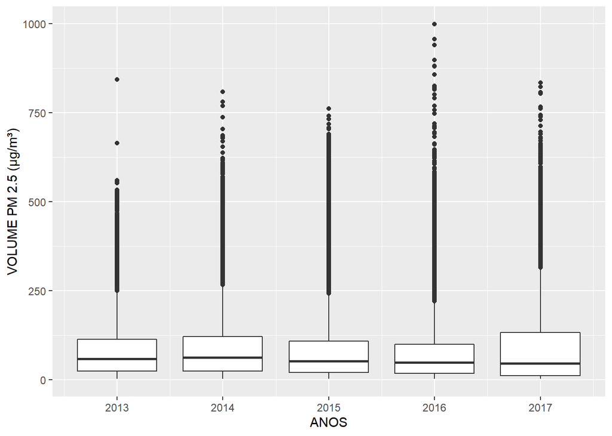

## **Sazonalidade Diária**

Neste indicador a OMS informa que o valor máximo deveria ser 25 μg/m³.

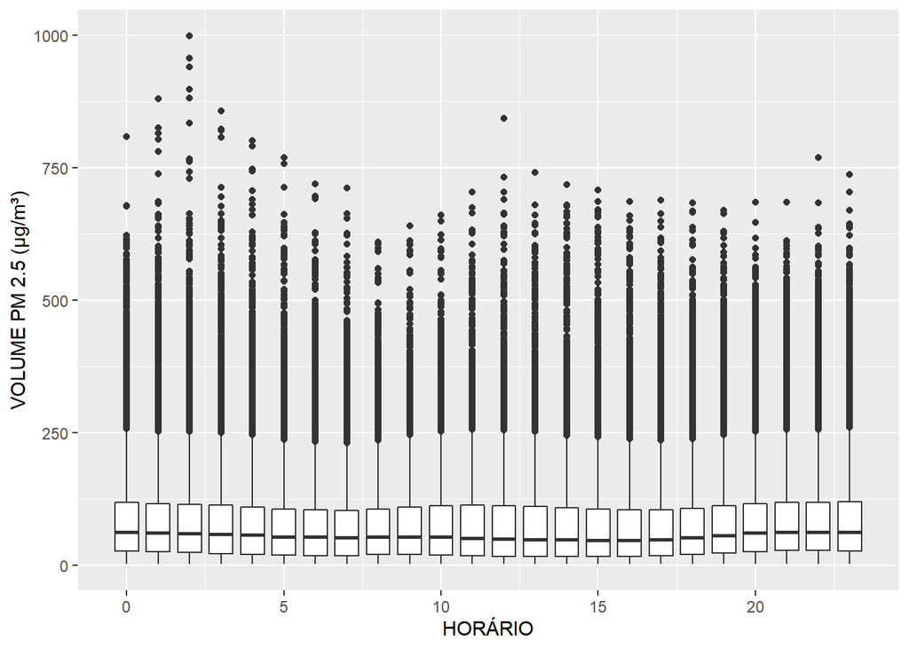

## **PM 2.5 por Estação**

Verificando a concentração de PM 2.5 por estação, constata-se que a estação de Dingling e Chengping possuem menor concentração, estas estações estão localizadas no subúrbio ao norte de Pequim, em uma área distante do centro da cidade.

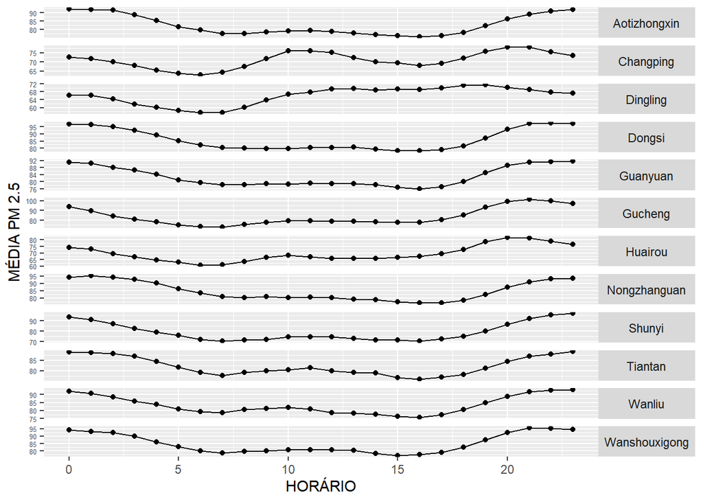

## **Heatmap**

Verifica-se que no heatmap o local com menor incidência de poluentes é **Dingling**, e com maior incidência é **Nongzhanguan**.

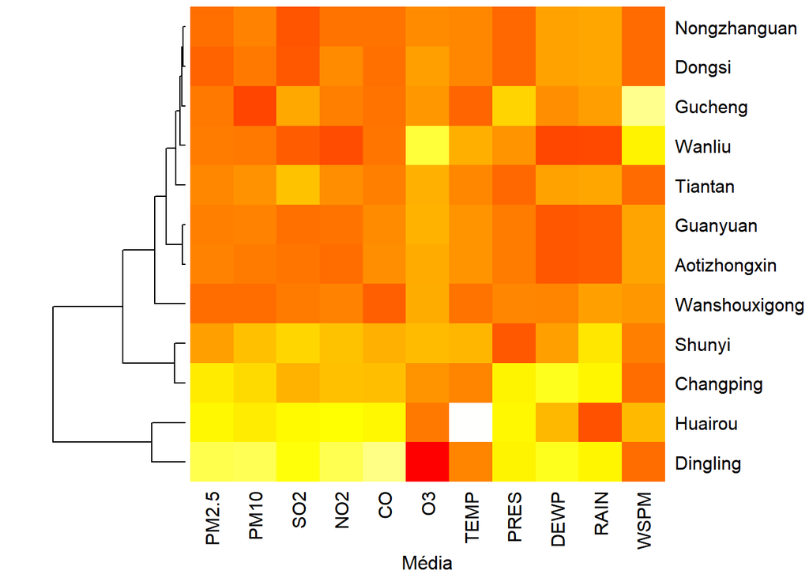

Analisando a mediana, percebe-se que a incidência de chuvas é baixa em todas as estações meteorológicas e verificando os níveis de poluentes há uma distinção entre os locais mais poluídos dos menos poluídos.

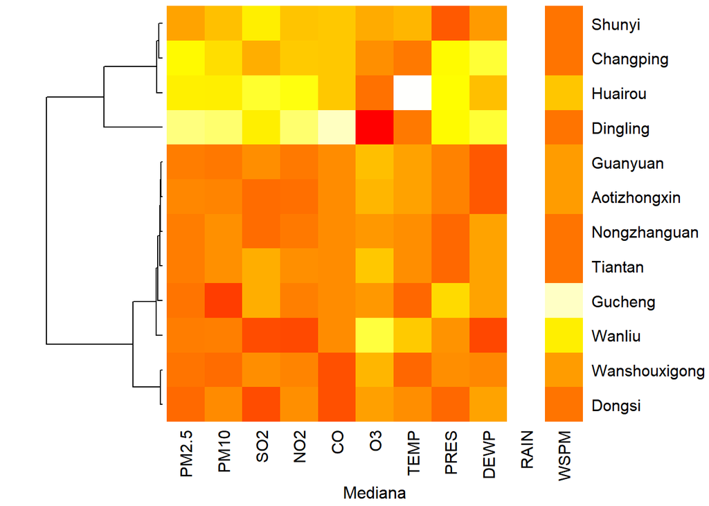

A análise da variância e o desvio padrão indicam o quanto as medições variaram no período, ou seja, mostra a estabilidade da qualidade do ar. Fazendo um paralelo com as análises anteriores, percebe-se que os locais mais poluídos possuem maior instabilidade.

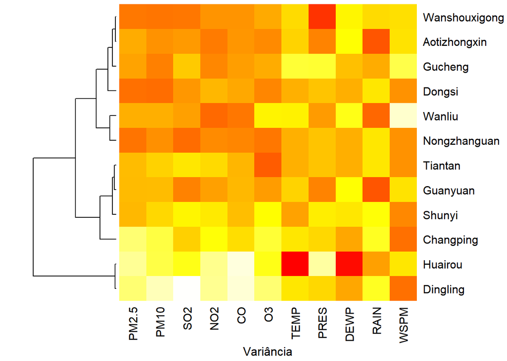

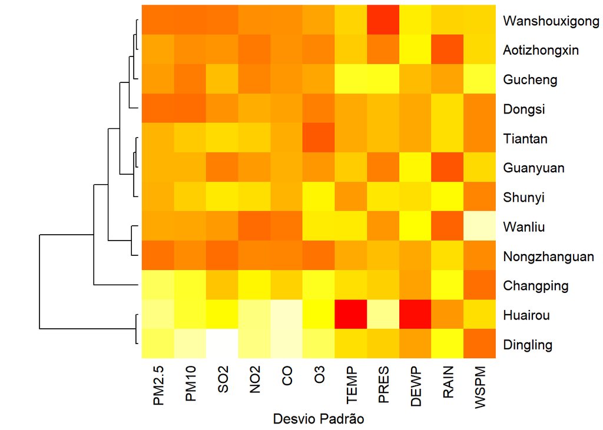

## Análise de Regressão

### **PM2.5 e Temperatura**

Verifica-se que essa correlação é forte, mostrando que quanto menor é a temperatura, maior é a concentração de PM2.5.

```
##
##  Shapiro-Wilk normality test
##
## data:  rstudent(reg1)
## W = 0.95661, p-value < 2.2e-16
```

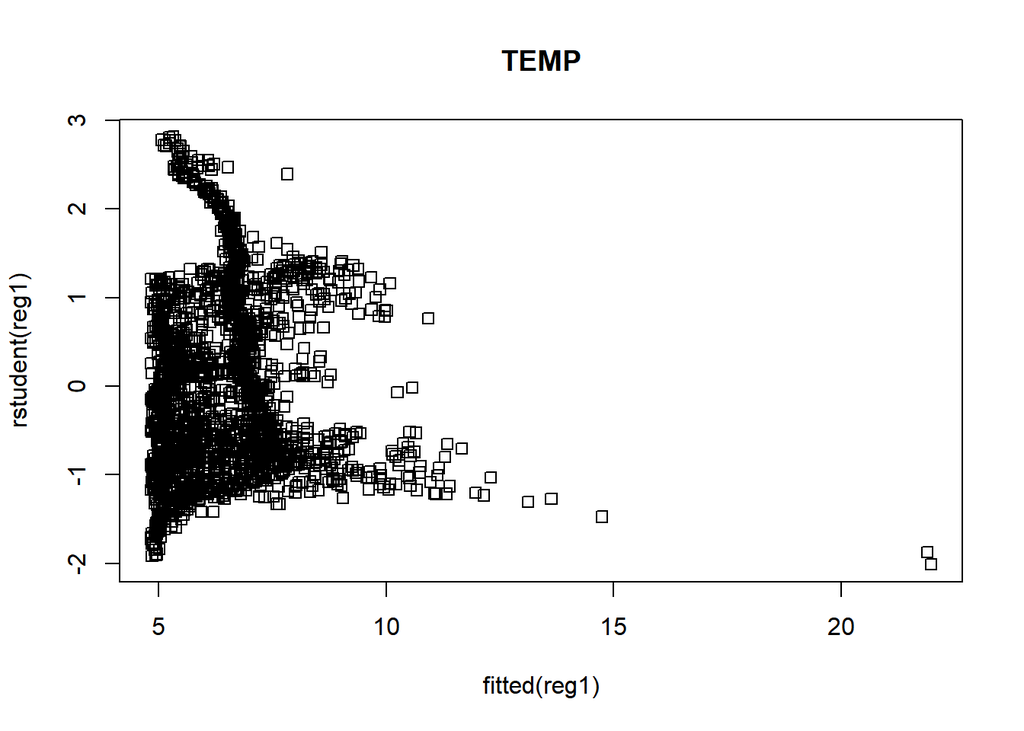

```
## integer(0)
```

### **PM2.5 e Chuva**

Neste teste vemos que quanto menor é a quantidade de chuva, maior é o acumulo de PM2.5.

```
##
##  Shapiro-Wilk normality test
##
## data:  rstudent(reg2)
## W = 0.90885, p-value = 3.36e-11
```

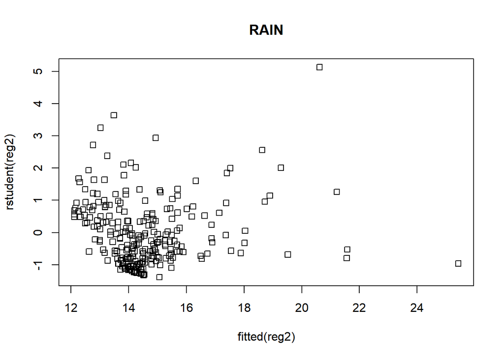

```
## integer(0)
```

### **PM2.5 e Dew Point** *(Ponto de orvalho)*

Neste teste verifica-se que há uma sazonalidade, mostrando que conforme a temperatura de Dew Point sofre variações, também altera a concentração de PM2.5 em uma correlação polinomial.

```
##
##  Shapiro-Wilk normality test
##
## data:  rstudent(reg3)
## W = 0.9559, p-value = 5.565e-13
```

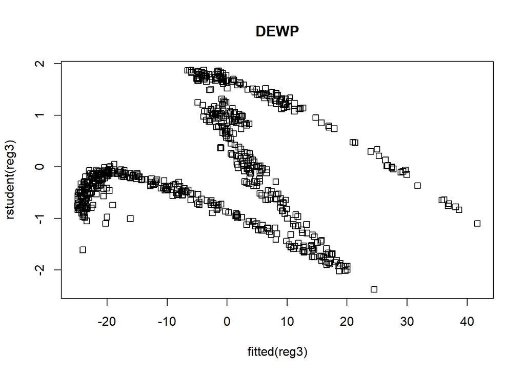

```
## integer(0)
```

### **PM2.5 e Velocidade do Vento**

A velocidade do vento influencia na dispersão das particulas PM2.5, sendo maior é a velocidade do vento, maior é a dispersão.

```
##
##  Shapiro-Wilk normality test
##
## data:  rstudent(reg4)
## W = 0.77309, p-value = 3.664e-12
```

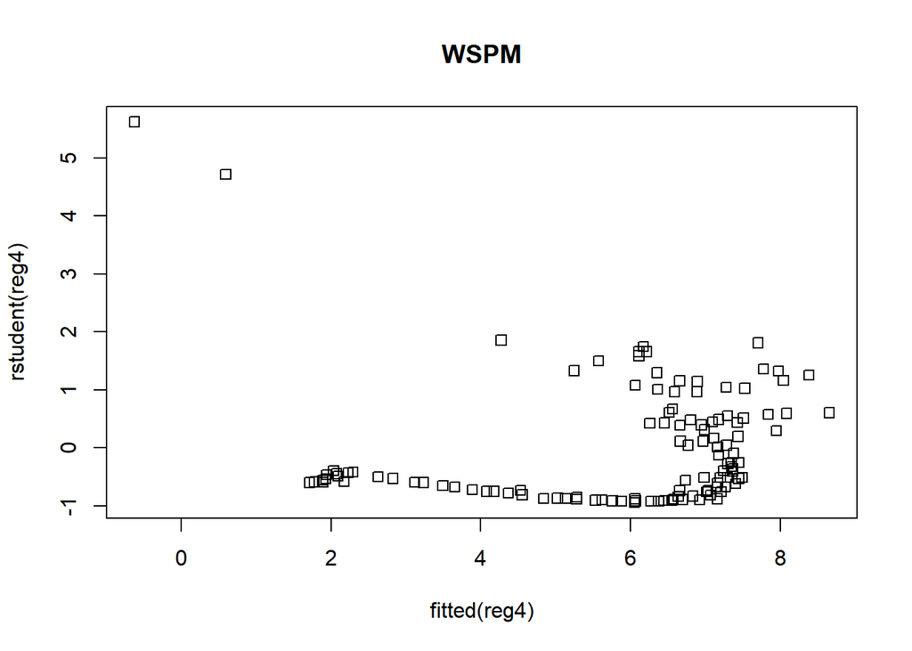

```
## integer(0)
```

### **Correlação Multivariada**

Nesta analise foram comparados os demais poluentes com o PM2.5.

Todos os poluentes tem correlação válida.

```
##
## Call:
## lm(formula = tab_clean$PM2.5 ~ tab_clean$PM10 + tab_clean$SO2 +
##     tab_clean$CO + tab_clean$NO2 + tab_clean$O3, data = tab_clean)
##
## Residuals:
##     Min      1Q  Median      3Q     Max
## -492.63  -13.02    0.74   12.24  673.14
##
## Coefficients:
##                  Estimate Std. Error  t value Pr(>|t|)
## (Intercept)    -1.629e+01  1.361e-01 -119.725  < 2e-16 ***
## tab_clean$PM10  5.443e-01  8.823e-04  616.964  < 2e-16 ***
## tab_clean$SO2  -2.414e-02  2.947e-03   -8.191 2.61e-16 ***
## tab_clean$CO    2.323e-02  7.293e-05  318.491  < 2e-16 ***
## tab_clean$NO2   1.281e-01  2.493e-03   51.386  < 2e-16 ***
## tab_clean$O3    7.227e-02  1.093e-03   66.094  < 2e-16 ***
## ---
## Signif. codes:  0 '***' 0.001 '**' 0.01 '*' 0.05 '.' 0.1 ' ' 1
##
## Residual standard error: 31.95 on 383974 degrees of freedom
##   (36788 observations deleted due to missingness)
## Multiple R-squared:  0.8412, Adjusted R-squared:  0.8412
## F-statistic: 4.069e+05 on 5 and 383974 DF,  p-value: < 2.2e-16
```

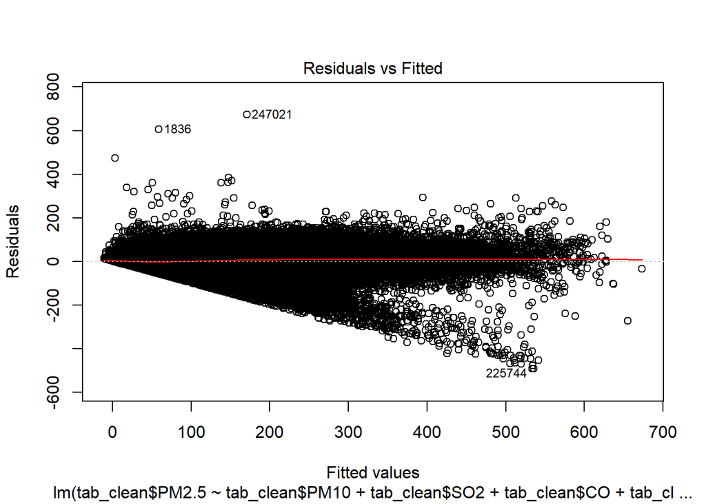

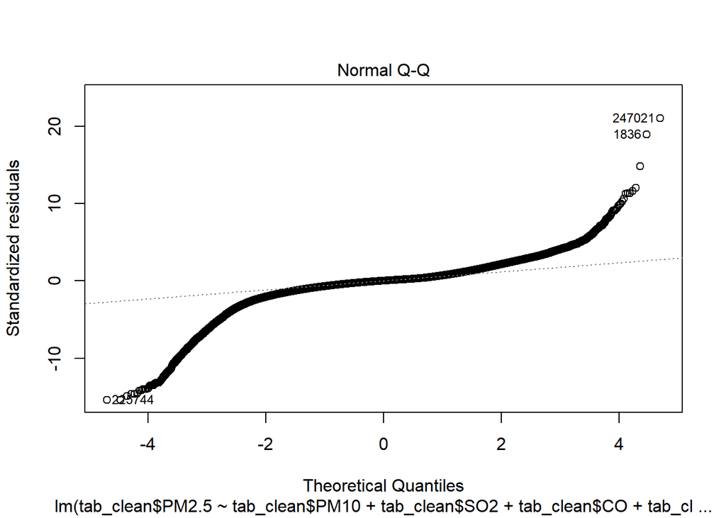

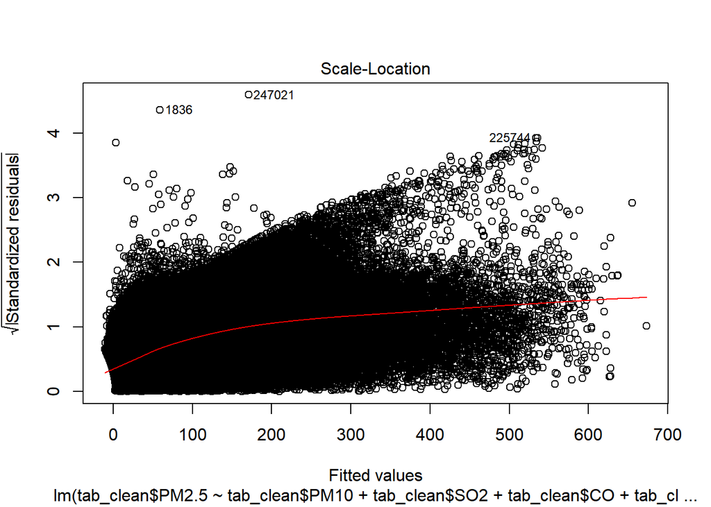

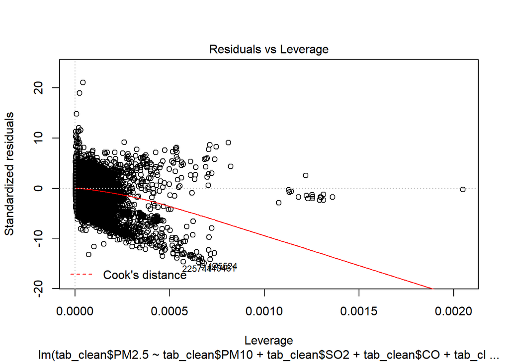

### **Forecasting de PM2.5**

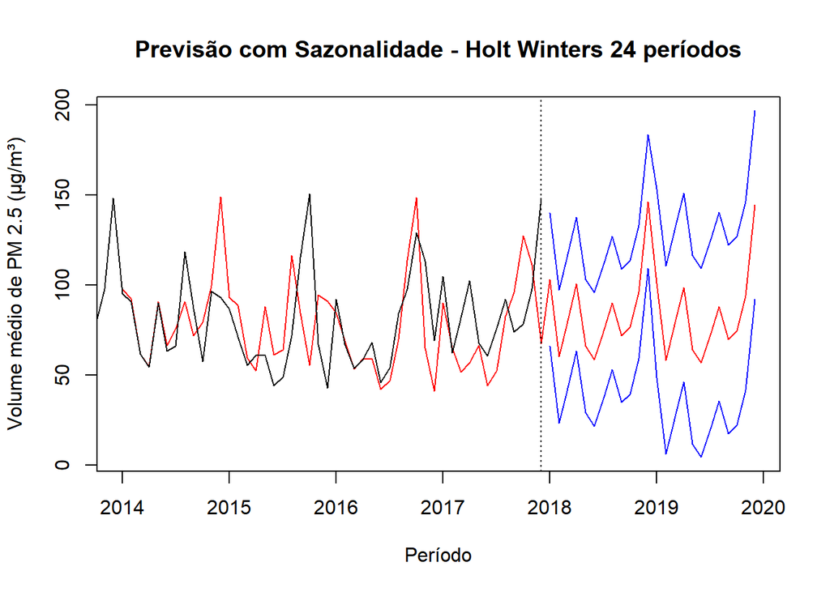

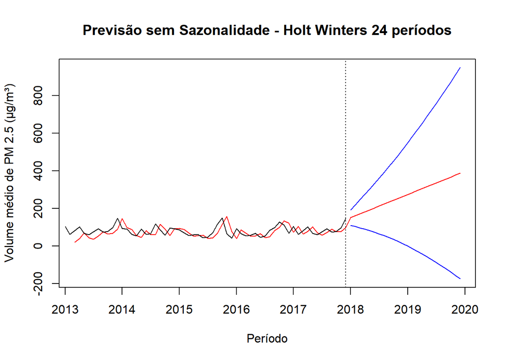